# Milestone2

## MSDS 430 Milestone 2

The following notebook analyzes the behavior of U.S. Wildfires between 1992 and 2015.

## U.S. Wildfires

Source: https://www.kaggle.com/rtatman/188-million-us-wildfires/download#FPA_FOD_20170508.sqlite

Source info: https://www.kaggle.com/rtatman/188-million-us-wildfires/

Dates: 1992 - 2015

Step 2 (5 pts.): Read in your data file and use pandas to inspect the first 5 lines and the last 5 lines.

```python
import pandas
import numpy as np
import matplotlib.pyplot as plt
import sqlite3
import seaborn as sns
import pandas_profiling
import stats
conn = sqlite3.connect("../data/FPA_FOD_20170508.sqlite")
cur = conn.cursor()
```

## Getting to understand the data

While Kaggle's documentation goes into detail about what's inside the SQLite file, I like to see for myself what tables are inside the instance I have in my memory, just to confirm they match. They do.

```python
cur.execute("SELECT name FROM sqlite_master WHERE type='table';")
output = cur.fetchall()
tables = [table[0] for table in output]
tables.sort() # sorting alphabetically for readability
print(tables)
```

```
['ElementaryGeometries', 'Fires', 'KNN', 'NWCG_UnitIDActive_20170109', 'SpatialIndex', 'geometry_columns', 'geometry_columns_auth', 'geometry_columns_field_infos', 'geometry_columns_statistics', 'geometry_columns_time', 'idx_Fires_Shape', 'idx_Fires_Shape_node', 'idx_Fires_Shape_parent', 'idx_Fires_…
```

Of the above tables, I think I only care about the Fires table.

## Getting column information

```python
query = cur.execute("SELECT * FROM fires;")
# this will point cur.description to the table fires

names = [description[0] for description in cur.description]
num_cols_fires = len(names)
# this I will not sort because the order should coordinate with data

print(names, "\n\n--> column count sqlite file : ", num_cols_fires)
```

```
['OBJECTID', 'FOD_ID', 'FPA_ID', 'SOURCE_SYSTEM_TYPE', 'SOURCE_SYSTEM', 'NWCG_REPORTING_AGENCY', 'NWCG_REPORTING_UNIT_ID', 'NWCG_REPORTING_UNIT_NAME', 'SOURCE_REPORTING_UNIT', 'SOURCE_REPORTING_UNIT_NAME', 'LOCAL_FIRE_REPORT_ID', 'LOCAL_INCIDENT_ID', 'FIRE_CODE', 'FIRE_NAME', 'ICS_209_INCIDENT_NUMBE…

--> column count sqlite file :  39
```

## SQLite Rowcount

Before converting into pandas Dataframe, want to know the number of rows in SQLite file to assert conversion was successful.

```python
cur.execute("SELECT COUNT(*) FROM fires;")
num_rows_fires = cur.fetchone()[0]
print("row count sqlite file : ", num_rows_fires)
# later we will confirm this is the same as in the dataframe
```

```
row count sqlite file :  1880465
```

```python
sqlite_dim = (num_rows_fires, num_cols_fires)
# storing sqlite dimension information for convenience
```

## Creating the dataframe from SQLite file

According to Kaggle's documentation, FOD_ID is the global unique identifier. This will become the pandas index column.

```python
df = pandas.read_sql("SELECT * FROM fires;", conn, index_col="FOD_ID")
```

```python
len(df) == num_rows_fires
```

```
True
```

Number of rows in both elements the same, which is good.

# First 5 elements

```python
df.head(5)
# first 5 elements
```

| FOD_ID | OBJECTID | FPA_ID | SOURCE_SYSTEM_TYPE | SOURCE_SYSTEM | NWCG_REPORTING_AGENCY | NWCG_REPORTING_UNIT_ID | NWCG_REPORTING_UNIT_NAME | SOURCE_REPORTING_UNIT | SOURCE_REPORTING_UNIT_NAME | LOCAL_FIRE_REPORT_ID | ... | FIRE_SIZE_CLASS | LATITUDE | LONGITUDE | OWNER_CODE | OWNER_DESCR | STATE | COUNTY | FIPS_CODE | FIPS_NAME | Shape |
| --- | --- | --- | --- | --- | --- | --- | --- | --- | --- | --- | --- | --- | --- | --- | --- | --- | --- | --- | --- | --- | --- |
| 1 | 1 | FS-1418826 | FED | FS-FIRESTAT | FS | USCAPNF | Plumas National Forest | 0511 | Plumas National Forest | 1 | ... | A | 40.036944 | -121.005833 | 5.0 | USFS | CA | 63 | 063 | Plumas | b'\x00\x01\xad\x10\x00\x00\xe8d\xc2\x92_@^\xc0... |
| 2 | 2 | FS-1418827 | FED | FS-FIRESTAT | FS | USCAENF | Eldorado National Forest | 0503 | Eldorado National Forest | 13 | ... | A | 38.933056 | -120.404444 | 5.0 | USFS | CA | 61 | 061 | Placer | b'\x00\x01\xad\x10\x00\x00T\xb6\xeej\xe2\x19^\... |
| 3 | 3 | FS-1418835 | FED | FS-FIRESTAT | FS | USCAENF | Eldorado National Forest | 0503 | Eldorado National Forest | 27 | ... | A | 38.984167 | -120.735556 | 13.0 | STATE OR PRIVATE | CA | 17 | 017 | El Dorado | b'\x00\x01\xad\x10\x00\x00\xd0\xa5\xa0W\x13/^\... |
| 4 | 4 | FS-1418845 | FED | FS-FIRESTAT | FS | USCAENF | Eldorado National Forest | 0503 | Eldorado National Forest | 43 | ... | A | 38.559167 | -119.913333 | 5.0 | USFS | CA | 3 | 003 | Alpine | b'\x00\x01\xad\x10\x00\x00\x94\xac\xa3\rt\xfa]... |
| 5 | 5 | FS-1418847 | FED | FS-FIRESTAT | FS | USCAENF | Eldorado National Forest | 0503 | Eldorado National Forest | 44 | ... | A | 38.559167 | -119.933056 | 5.0 | USFS | CA | 3 | 003 | Alpine | b'\x00\x01\xad\x10\x00\x00@\xe3\xaa.\xb7\xfb]\... |

5 rows × 38 columns

# Last 5 elements

```python
df.tail(5)
# last 5 elements
```

| FOD_ID | OBJECTID | FPA_ID | SOURCE_SYSTEM_TYPE | SOURCE_SYSTEM | NWCG_REPORTING_AGENCY | NWCG_REPORTING_UNIT_ID | NWCG_REPORTING_UNIT_NAME | SOURCE_REPORTING_UNIT | SOURCE_REPORTING_UNIT_NAME | LOCAL_FIRE_REPORT_ID | ... | FIRE_SIZE_CLASS | LATITUDE | LONGITUDE | OWNER_CODE | OWNER_DESCR | STATE | COUNTY | FIPS_CODE | FIPS_NAME | Shape |
| --- | --- | --- | --- | --- | --- | --- | --- | --- | --- | --- | --- | --- | --- | --- | --- | --- | --- | --- | --- | --- | --- |
| 300348363 | 1880461 | 2015CAIRS29019636 | NONFED | ST-CACDF | ST/C&L | USCASHU | Shasta-Trinity Unit | CASHU | Shasta-Trinity Unit | 591814 | ... | A | 40.481637 | -122.389375 | 13.0 | STATE OR PRIVATE | CA | None | None | None | b'\x00\x01\xad\x10\x00\x00P\xb8\x1e\x85\xeb\x9... |
| 300348373 | 1880462 | 2015CAIRS29217935 | NONFED | ST-CACDF | ST/C&L | USCATCU | Tuolumne-Calaveras Unit | CATCU | Tuolumne-Calaveras Unit | 569419 | ... | A | 37.617619 | -120.938570 | 12.0 | MUNICIPAL/LOCAL | CA | None | None | None | b'\x00\x01\xad\x10\x00\x00\x00\x80\xbe\x88\x11... |
| 300348375 | 1880463 | 2015CAIRS28364460 | NONFED | ST-CACDF | ST/C&L | USCATCU | Tuolumne-Calaveras Unit | CATCU | Tuolumne-Calaveras Unit | 574245 | ... | A | 37.617619 | -120.938570 | 12.0 | MUNICIPAL/LOCAL | CA | None | None | None | b'\x00\x01\xad\x10\x00\x00\x00\x80\xbe\x88\x11... |
| 300348377 | 1880464 | 2015CAIRS29218079 | NONFED | ST-CACDF | ST/C&L | USCATCU | Tuolumne-Calaveras Unit | CATCU | Tuolumne-Calaveras Unit | 570462 | ... | B | 37.672235 | -120.898356 | 12.0 | MUNICIPAL/LOCAL | CA | None | None | None | b'\x00\x01\xad\x10\x00\x00x\xba_\xaa~9^\xc0\xb... |
| 300348399 | 1880465 | 2015CAIRS26733926 | NONFED | ST-CACDF | ST/C&L | USCABDU | San Bernardino Unit | CABDU | CDF - San Bernardino Unit | 535436 | ... | A | 34.263217 | -116.830950 | 13.0 | STATE OR PRIVATE | CA | None | None | None | b'\x00\x01\xad\x10\x00\x00\x1c\xa7\xe8H.5]\xc0... |

5 rows × 38 columns

Step 3 (5 pts.): Use numpy to perform a few calculations relevant to your goals for the final project. Explain each calculation by including comments within your code.

## Relevant Calculations

1. Extracting California information from US-wide Dataset
2. Basic descriptive statistics
3. Fire frequency by year

```python
# Extracting CA info

CA = df[df['STATE']=='CA']
CA.head()
```

| FOD_ID | OBJECTID | FPA_ID | SOURCE_SYSTEM_TYPE | SOURCE_SYSTEM | NWCG_REPORTING_AGENCY | NWCG_REPORTING_UNIT_ID | NWCG_REPORTING_UNIT_NAME | SOURCE_REPORTING_UNIT | SOURCE_REPORTING_UNIT_NAME | LOCAL_FIRE_REPORT_ID | ... | FIRE_SIZE_CLASS | LATITUDE | LONGITUDE | OWNER_CODE | OWNER_DESCR | STATE | COUNTY | FIPS_CODE | FIPS_NAME | Shape |
| --- | --- | --- | --- | --- | --- | --- | --- | --- | --- | --- | --- | --- | --- | --- | --- | --- | --- | --- | --- | --- | --- |
| 1 | 1 | FS-1418826 | FED | FS-FIRESTAT | FS | USCAPNF | Plumas National Forest | 0511 | Plumas National Forest | 1 | ... | A | 40.036944 | -121.005833 | 5.0 | USFS | CA | 63 | 063 | Plumas | b'\x00\x01\xad\x10\x00\x00\xe8d\xc2\x92_@^\xc0... |
| 2 | 2 | FS-1418827 | FED | FS-FIRESTAT | FS | USCAENF | Eldorado National Forest | 0503 | Eldorado National Forest | 13 | ... | A | 38.933056 | -120.404444 | 5.0 | USFS | CA | 61 | 061 | Placer | b'\x00\x01\xad\x10\x00\x00T\xb6\xeej\xe2\x19^\... |
| 3 | 3 | FS-1418835 | FED | FS-FIRESTAT | FS | USCAENF | Eldorado National Forest | 0503 | Eldorado National Forest | 27 | ... | A | 38.984167 | -120.735556 | 13.0 | STATE OR PRIVATE | CA | 17 | 017 | El Dorado | b'\x00\x01\xad\x10\x00\x00\xd0\xa5\xa0W\x13/^\... |
| 4 | 4 | FS-1418845 | FED | FS-FIRESTAT | FS | USCAENF | Eldorado National Forest | 0503 | Eldorado National Forest | 43 | ... | A | 38.559167 | -119.913333 | 5.0 | USFS | CA | 3 | 003 | Alpine | b'\x00\x01\xad\x10\x00\x00\x94\xac\xa3\rt\xfa]... |
| 5 | 5 | FS-1418847 | FED | FS-FIRESTAT | FS | USCAENF | Eldorado National Forest | 0503 | Eldorado National Forest | 44 | ... | A | 38.559167 | -119.933056 | 5.0 | USFS | CA | 3 | 003 | Alpine | b'\x00\x01\xad\x10\x00\x00@\xe3\xaa.\xb7\xfb]\... |

5 rows × 38 columns

```python
# descriptive statistics

CA.describe()
```

|  | OBJECTID | FIRE_YEAR | DISCOVERY_DATE | DISCOVERY_DOY | STAT_CAUSE_CODE | CONT_DATE | CONT_DOY | FIRE_SIZE | LATITUDE | LONGITUDE | OWNER_CODE |
| --- | --- | --- | --- | --- | --- | --- | --- | --- | --- | --- | --- |
| count | 1.895500e+05 | 189550.000000 | 1.895500e+05 | 189550.000000 | 189550.000000 | 9.190800e+04 | 91908.000000 | 189550.000000 | 189550.000000 | 189550.000000 | 189550.000000 |
| mean | 9.353992e+05 | 2003.118275 | 2.452884e+06 | 201.594571 | 5.690725 | 2.453347e+06 | 203.607727 | 67.242725 | 37.434167 | -120.182292 | 10.767038 |
| std | 5.864817e+05 | 7.007634 | 2.554377e+03 | 65.936299 | 3.677568 | 2.563014e+03 | 65.127623 | 2029.960435 | 2.591567 | 2.155615 | 4.402412 |
| min | 1.000000e+00 | 1992.000000 | 2.448622e+06 | 1.000000 | 1.000000 | 2.448622e+06 | 1.000000 | 0.001000 | 32.537406 | -124.402883 | 0.000000 |
| 25% | 3.112172e+05 | 1997.000000 | 2.450624e+06 | 164.000000 | 2.000000 | 2.451362e+06 | 169.000000 | 0.100000 | 35.177688 | -121.721944 | 6.000000 |
| 50% | 1.096222e+06 | 2003.000000 | 2.452860e+06 | 202.000000 | 5.000000 | 2.453248e+06 | 206.000000 | 0.250000 | 37.565062 | -120.530316 | 14.000000 |
| 75% | 1.143609e+06 | 2009.000000 | 2.455034e+06 | 245.000000 | 9.000000 | 2.455763e+06 | 246.000000 | 1.000000 | 39.475208 | -118.595503 | 14.000000 |
| max | 1.880465e+06 | 2015.000000 | 2.457388e+06 | 366.000000 | 13.000000 | 2.457388e+06 | 366.000000 | 315578.800000 | 42.051667 | -114.125800 | 15.000000 |

```python
len(CA)
```

```
189550
```

```python
print("CA is about {} % of the total dataset".format(round(len(CA)/num_rows_fires*100, 2)))
```

```
CA is about 10.08 % of the total dataset
```

```python
# missings

CA.isnull().sum()
```

```
OBJECTID                           0
FPA_ID                             0
SOURCE_SYSTEM_TYPE                 0
SOURCE_SYSTEM                      0
NWCG_REPORTING_AGENCY              0
NWCG_REPORTING_UNIT_ID             0
NWCG_REPORTING_UNIT_NAME           0
SOURCE_REPORTING_UNIT              0
SOURCE_REPORTING_UNIT_NAME         0
LOCAL_FIRE_REPORT_ID          127617
LOCAL_INCIDENT_ID              61567
FIRE_CODE                     134017
FIRE_NAME                      14993
ICS_209_INCIDENT_NUMBER       186712
ICS_209_NAME                  186712
MTBS_ID                       188413
MTBS_FIRE_NAME                188413
COMPLEX_NAME                  188623
FIRE_YEAR                          0
DISCOVERY_DATE                     0
DISCOVERY_DOY                      0
DISCOVERY_TIME                 79333
STAT_CAUSE_CODE                    0
STAT_CAUSE_DESCR                   0
CONT_DATE                      97642
CONT_DOY                       97642
CONT_TIME                      98333
FIRE_SIZE                          0
FIRE_SIZE_CLASS                    0
LATITUDE                           0
LONGITUDE                          0
OWNER_CODE                         0
OWNER_DESCR                        0
STATE                              0
COUNTY                        133329
FIPS_CODE                     133329
FIPS_NAME                     133329
Shape                              0
dtype: int64
```

```python
# missings as a proportion to population

proportions = 100 * (round(CA.isnull().sum() / len(CA), 4))

print(proportions)
```

```
OBJECTID                       0.00
FPA_ID                         0.00
SOURCE_SYSTEM_TYPE             0.00
SOURCE_SYSTEM                  0.00
NWCG_REPORTING_AGENCY          0.00
NWCG_REPORTING_UNIT_ID         0.00
NWCG_REPORTING_UNIT_NAME       0.00
SOURCE_REPORTING_UNIT          0.00
SOURCE_REPORTING_UNIT_NAME     0.00
LOCAL_FIRE_REPORT_ID          67.33
LOCAL_INCIDENT_ID             32.48
FIRE_CODE                     70.70
FIRE_NAME                      7.91
ICS_209_INCIDENT_NUMBER       98.50
ICS_209_NAME                  98.50
MTBS_ID                       99.40
MTBS_FIRE_NAME                99.40
COMPLEX_NAME                  99.51
FIRE_YEAR                      0.00
DISCOVERY_DATE                 0.00
DISCOVERY_DOY                  0.00
DISCOVERY_TIME                41.85
STAT_CAUSE_CODE                0.00
STAT_CAUSE_DESCR               0.00
CONT_DATE                     51.51
CONT_DOY                      51.51
CONT_TIME                     51.88
FIRE_SIZE                      0.00
FIRE_SIZE_CLASS                0.00
LATITUDE                       0.00
LONGITUDE                      0.00
OWNER_CODE                     0.00
OWNER_DESCR                    0.00
STATE                          0.00
COUNTY                        70.34
FIPS_CODE                     70.34
FIPS_NAME                     70.34
Shape                          0.00
dtype: float64
```

```python
CA.dtypes
```

```
OBJECTID                        int64
FPA_ID                         object
SOURCE_SYSTEM_TYPE             object
SOURCE_SYSTEM                  object
NWCG_REPORTING_AGENCY          object
NWCG_REPORTING_UNIT_ID         object
NWCG_REPORTING_UNIT_NAME       object
SOURCE_REPORTING_UNIT          object
SOURCE_REPORTING_UNIT_NAME     object
LOCAL_FIRE_REPORT_ID           object
LOCAL_INCIDENT_ID              object
FIRE_CODE                      object
FIRE_NAME                      object
ICS_209_INCIDENT_NUMBER        object
ICS_209_NAME                   object
MTBS_ID                        object
MTBS_FIRE_NAME                 object
COMPLEX_NAME                   object
FIRE_YEAR                       int64
DISCOVERY_DATE                float64
DISCOVERY_DOY                   int64
DISCOVERY_TIME                 object
STAT_CAUSE_CODE               float64
STAT_CAUSE_DESCR               object
CONT_DATE                     float64
CONT_DOY                      float64
CONT_TIME                      object
FIRE_SIZE                     float64
FIRE_SIZE_CLASS                object
LATITUDE                      float64
LONGITUDE                     float64
OWNER_CODE                    float64
OWNER_DESCR                    object
STATE                          object
COUNTY                         object
FIPS_CODE                      object
FIPS_NAME                      object
Shape                          object
dtype: object
```

Of any of the above columns that has a proportion of missings greater than 0, I need to make some decisions. Anything higher than like, 80% I'm just going to drop without question. Some columns could be interesting though despite having such a high missing rate.

```python
# DISCOVERY_TIME
times = list(CA["DISCOVERY_TIME"].unique())
list(CA["DISCOVERY_TIME"].unique())
# printing like this makes it one per line, which I prefer
```

```
['1300',
 '0845',
 '1921',
 '1600',
 '1800',
 '1200',
 '1830',
 '1730',
 '0630',
 '0930',
 '1415',
 '1618',
 '2000',
 '1007',
 '0710',
 '1650',
 '0905',
 '1145',
 '0015',
 '1700',
 '1500',
 '2015',
 '1530',
 '1628',
 '1337',
 '1640',
 '1915',
 '1000',
 '1630',
 '1523',
 '1756',
 '1609',
 '1551',
 '1330',
 '1702',
 '0315',
 '0545',
 '1456',
 '1816',
 '1031',
```

[output cut: 946 more lines]

```
 '0613',
 '1342',
 '0559',
 '0740',
 '2027',
 '0733',
 '0544',
 '0543',
 '2218',
 '0851',
 '0822',
 '0806',
 '1026',
 '1852',
 ...]
```

```python
'9999' in times
```

```
False
```

DISCOVERY_TIME is about 40% missing but could be interesting to explore. So I'll use a legitimate time to represent a missing, to manipulate any program to work on the column but so the data scientist can understand that is what was missing.

It's an object, not a date. The above cell goes into seeing what some of the values look like, to replace it with something that hasn't been used, but still conforms to the pattern.

Looks like discovery time is entered without the colon using 4 characters in 24-hour format. For example, midnight would be 0000 and 2:15 pm would be 1415.

Replacing NaN's with 9999, since it should conform to the rest but it's not a real time so it wouldn't be mistaken for a real data point.

```python
CA["DISCOVERY_TIME"].fillna("9999", inplace=True)
```

Same with Fire Name.

```python
CA["COUNTY"].fillna("Not Specified", inplace=True)
CA["FIRE_NAME"].fillna("Not Specified", inplace=True)
```

```python
# dropping useless columns

CA.drop(columns = ["ICS_209_INCIDENT_NUMBER", "ICS_209_NAME", "LOCAL_INCIDENT_ID",
                   "MTBS_ID", "MTBS_FIRE_NAME", "COMPLEX_NAME",
                  "COUNTY", "FIPS_CODE", "FIPS_NAME", "LOCAL_FIRE_REPORT_ID",
                  "OWNER_CODE", "FIRE_CODE", "CONT_TIME", "CONT_DOY", "CONT_DATE"], inplace = True)
```

```python
"ICS_209_INCIDENT_NUMBER" in CA.columns # checking the drop worked correctly
```

```
False
```

```python
new_proportions = 100 * (round(CA.isnull().sum() / len(CA), 4))

print(new_proportions)
```

```
OBJECTID                      0.0
FPA_ID                        0.0
SOURCE_SYSTEM_TYPE            0.0
SOURCE_SYSTEM                 0.0
NWCG_REPORTING_AGENCY         0.0
NWCG_REPORTING_UNIT_ID        0.0
NWCG_REPORTING_UNIT_NAME      0.0
SOURCE_REPORTING_UNIT         0.0
SOURCE_REPORTING_UNIT_NAME    0.0
FIRE_NAME                     0.0
FIRE_YEAR                     0.0
DISCOVERY_DATE                0.0
DISCOVERY_DOY                 0.0
DISCOVERY_TIME                0.0
STAT_CAUSE_CODE               0.0
STAT_CAUSE_DESCR              0.0
FIRE_SIZE                     0.0
FIRE_SIZE_CLASS               0.0
LATITUDE                      0.0
LONGITUDE                     0.0
OWNER_DESCR                   0.0
STATE                         0.0
Shape                         0.0
dtype: float64
```

Step 4 (5 pts.): Use matplotlib to create a visual display relevant to your goals for the final project. Explain your graph by including comments within your code.

## Using matplotlib to visualize California wildfire frequencies over time

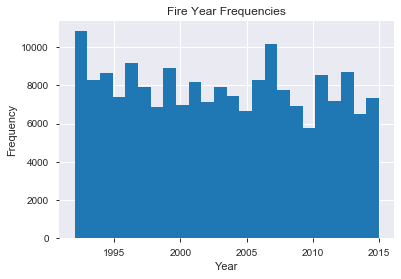

```python
# This gives a frequency distribution of all the years

years = CA["FIRE_YEAR"]
plt.hist(years, bins=len(CA["FIRE_YEAR"].unique()))
plt.title("Fire Year Frequencies")
plt.xlabel("Year")
plt.ylabel("Frequency")
plt.show()
```

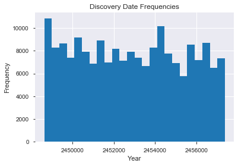

```python
# curious about discovery date, how or if it differs

plt.hist(CA["DISCOVERY_DATE"], bins=len(CA["FIRE_YEAR"].unique()))
plt.title("Discovery Date Frequencies")
plt.xlabel("Year")
plt.ylabel("Frequency")
plt.show()
```

```python
# filtering for only numeric datatypes in prep for Pearson coefficiant

numerics = ['int16', 'int32', 'int64', 'float16', 'float32', 'float64']

CA_numerics = CA.select_dtypes(include=numerics)
CA_numerics.columns
```

```
Index(['OBJECTID', 'FIRE_YEAR', 'DISCOVERY_DATE', 'DISCOVERY_DOY',
       'STAT_CAUSE_CODE', 'FIRE_SIZE', 'LATITUDE', 'LONGITUDE'],
      dtype='object')
```

```python
CA_numerics.drop(columns="OBJECTID", inplace=True) # another ID; not necessary for data exploratory analysis
```

# Seaborn for practical scatter plots including the Pearson coefficient. Commenting out because it takes 10 minutes to run.

```python
CA_categorics = CA.select_dtypes(include="object")
CA_categorics.columns
```

```
Index(['FPA_ID', 'SOURCE_SYSTEM_TYPE', 'SOURCE_SYSTEM',
       'NWCG_REPORTING_AGENCY', 'NWCG_REPORTING_UNIT_ID',
       'NWCG_REPORTING_UNIT_NAME', 'SOURCE_REPORTING_UNIT',
       'SOURCE_REPORTING_UNIT_NAME', 'FIRE_NAME', 'DISCOVERY_TIME',
       'STAT_CAUSE_DESCR', 'FIRE_SIZE_CLASS', 'OWNER_DESCR', 'STATE', 'Shape'],
      dtype='object')
```

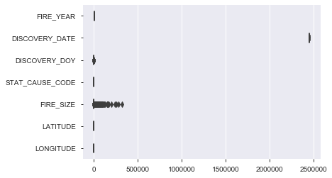

```python
sns.boxplot(data=CA_numerics, orient="h", width=0.4)
#sns.swarmplot(CA_categorics)
```

```python
CA_numerics.columns
```

```
Index(['FIRE_YEAR', 'DISCOVERY_DATE', 'DISCOVERY_DOY', 'STAT_CAUSE_CODE',
       'FIRE_SIZE', 'LATITUDE', 'LONGITUDE'],
      dtype='object')
```

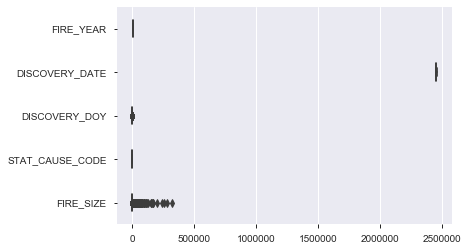

```python
one_shot = CA_numerics.drop(columns = ["LATITUDE", "LONGITUDE"])
sns.boxplot(data=one_shot, orient="h", width=0.4)
```

```python
#sns.catplot(CA_categorics) # categoricals only maybs
#sns.catplot(CA["STATE"])
```

```python
CA.isnull().sum()
```

```
OBJECTID                      0
FPA_ID                        0
SOURCE_SYSTEM_TYPE            0
SOURCE_SYSTEM                 0
NWCG_REPORTING_AGENCY         0
NWCG_REPORTING_UNIT_ID        0
NWCG_REPORTING_UNIT_NAME      0
SOURCE_REPORTING_UNIT         0
SOURCE_REPORTING_UNIT_NAME    0
FIRE_NAME                     0
FIRE_YEAR                     0
DISCOVERY_DATE                0
DISCOVERY_DOY                 0
DISCOVERY_TIME                0
STAT_CAUSE_CODE               0
STAT_CAUSE_DESCR              0
FIRE_SIZE                     0
FIRE_SIZE_CLASS               0
LATITUDE                      0
LONGITUDE                     0
OWNER_DESCR                   0
STATE                         0
Shape                         0
dtype: int64
```

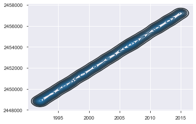

```python
sns.kdeplot(CA_numerics)

# this tells me there's still some garbage to clean up;
# moreover, I think keeping CA only is a mistake
```

```python
df.isnull().sum()
```

```
OBJECTID                            0
FPA_ID                              0
SOURCE_SYSTEM_TYPE                  0
SOURCE_SYSTEM                       0
NWCG_REPORTING_AGENCY               0
NWCG_REPORTING_UNIT_ID              0
NWCG_REPORTING_UNIT_NAME            0
SOURCE_REPORTING_UNIT               0
SOURCE_REPORTING_UNIT_NAME          0
LOCAL_FIRE_REPORT_ID          1459286
LOCAL_INCIDENT_ID              820821
FIRE_CODE                     1555636
FIRE_NAME                      957189
ICS_209_INCIDENT_NUMBER       1854748
ICS_209_NAME                  1854748
MTBS_ID                       1869462
MTBS_FIRE_NAME                1869462
COMPLEX_NAME                  1875282
FIRE_YEAR                           0
DISCOVERY_DATE                      0
DISCOVERY_DOY                       0
DISCOVERY_TIME                 882638
STAT_CAUSE_CODE                     0
STAT_CAUSE_DESCR                    0
CONT_DATE                      891531
CONT_DOY                       891531
CONT_TIME                      972173
FIRE_SIZE                           0
FIRE_SIZE_CLASS                     0
LATITUDE                            0
LONGITUDE                           0
OWNER_CODE                          0
OWNER_DESCR                         0
STATE                               0
COUNTY                         678148
FIPS_CODE                      678148
FIPS_NAME                      678148
Shape                               0
dtype: int64
```

```python
df.drop(columns = ["ICS_209_INCIDENT_NUMBER", "ICS_209_NAME", "LOCAL_INCIDENT_ID",
                   "MTBS_ID", "MTBS_FIRE_NAME", "COMPLEX_NAME",
                  "FIPS_CODE", "FIPS_NAME", "LOCAL_FIRE_REPORT_ID",
                  "OWNER_CODE", "FIRE_CODE", "CONT_TIME", "CONT_DOY", "CONT_DATE"], inplace = True)
```

```python
df.isnull().sum()
```

```
OBJECTID                           0
FPA_ID                             0
SOURCE_SYSTEM_TYPE                 0
SOURCE_SYSTEM                      0
NWCG_REPORTING_AGENCY              0
NWCG_REPORTING_UNIT_ID             0
NWCG_REPORTING_UNIT_NAME           0
SOURCE_REPORTING_UNIT              0
SOURCE_REPORTING_UNIT_NAME         0
FIRE_NAME                     957189
FIRE_YEAR                          0
DISCOVERY_DATE                     0
DISCOVERY_DOY                      0
DISCOVERY_TIME                882638
STAT_CAUSE_CODE                    0
STAT_CAUSE_DESCR                   0
FIRE_SIZE                          0
FIRE_SIZE_CLASS                    0
LATITUDE                           0
LONGITUDE                          0
OWNER_DESCR                        0
STATE                              0
COUNTY                        678148
Shape                              0
dtype: int64
```

```python
df.head()
```

| FOD_ID | OBJECTID | FPA_ID | SOURCE_SYSTEM_TYPE | SOURCE_SYSTEM | NWCG_REPORTING_AGENCY | NWCG_REPORTING_UNIT_ID | NWCG_REPORTING_UNIT_NAME | SOURCE_REPORTING_UNIT | SOURCE_REPORTING_UNIT_NAME | FIRE_NAME | ... | STAT_CAUSE_CODE | STAT_CAUSE_DESCR | FIRE_SIZE | FIRE_SIZE_CLASS | LATITUDE | LONGITUDE | OWNER_DESCR | STATE | COUNTY | Shape |
| --- | --- | --- | --- | --- | --- | --- | --- | --- | --- | --- | --- | --- | --- | --- | --- | --- | --- | --- | --- | --- | --- |
| 1 | 1 | FS-1418826 | FED | FS-FIRESTAT | FS | USCAPNF | Plumas National Forest | 0511 | Plumas National Forest | FOUNTAIN | ... | 9.0 | Miscellaneous | 0.10 | A | 40.036944 | -121.005833 | USFS | CA | 63 | b'\x00\x01\xad\x10\x00\x00\xe8d\xc2\x92_@^\xc0... |
| 2 | 2 | FS-1418827 | FED | FS-FIRESTAT | FS | USCAENF | Eldorado National Forest | 0503 | Eldorado National Forest | PIGEON | ... | 1.0 | Lightning | 0.25 | A | 38.933056 | -120.404444 | USFS | CA | 61 | b'\x00\x01\xad\x10\x00\x00T\xb6\xeej\xe2\x19^\... |
| 3 | 3 | FS-1418835 | FED | FS-FIRESTAT | FS | USCAENF | Eldorado National Forest | 0503 | Eldorado National Forest | SLACK | ... | 5.0 | Debris Burning | 0.10 | A | 38.984167 | -120.735556 | STATE OR PRIVATE | CA | 17 | b'\x00\x01\xad\x10\x00\x00\xd0\xa5\xa0W\x13/^\... |
| 4 | 4 | FS-1418845 | FED | FS-FIRESTAT | FS | USCAENF | Eldorado National Forest | 0503 | Eldorado National Forest | DEER | ... | 1.0 | Lightning | 0.10 | A | 38.559167 | -119.913333 | USFS | CA | 3 | b'\x00\x01\xad\x10\x00\x00\x94\xac\xa3\rt\xfa]... |
| 5 | 5 | FS-1418847 | FED | FS-FIRESTAT | FS | USCAENF | Eldorado National Forest | 0503 | Eldorado National Forest | STEVENOT | ... | 1.0 | Lightning | 0.10 | A | 38.559167 | -119.933056 | USFS | CA | 3 | b'\x00\x01\xad\x10\x00\x00@\xe3\xaa.\xb7\xfb]\... |

5 rows × 24 columns

```python
df.index = df["FPA_ID"]
```

```python
df.head()
```

| FPA_ID | OBJECTID | FPA_ID | SOURCE_SYSTEM_TYPE | SOURCE_SYSTEM | NWCG_REPORTING_AGENCY | NWCG_REPORTING_UNIT_ID | NWCG_REPORTING_UNIT_NAME | SOURCE_REPORTING_UNIT | SOURCE_REPORTING_UNIT_NAME | FIRE_NAME | ... | STAT_CAUSE_CODE | STAT_CAUSE_DESCR | FIRE_SIZE | FIRE_SIZE_CLASS | LATITUDE | LONGITUDE | OWNER_DESCR | STATE | COUNTY | Shape |
| --- | --- | --- | --- | --- | --- | --- | --- | --- | --- | --- | --- | --- | --- | --- | --- | --- | --- | --- | --- | --- | --- |
| FS-1418826 | 1 | FS-1418826 | FED | FS-FIRESTAT | FS | USCAPNF | Plumas National Forest | 0511 | Plumas National Forest | FOUNTAIN | ... | 9.0 | Miscellaneous | 0.10 | A | 40.036944 | -121.005833 | USFS | CA | 63 | b'\x00\x01\xad\x10\x00\x00\xe8d\xc2\x92_@^\xc0... |
| FS-1418827 | 2 | FS-1418827 | FED | FS-FIRESTAT | FS | USCAENF | Eldorado National Forest | 0503 | Eldorado National Forest | PIGEON | ... | 1.0 | Lightning | 0.25 | A | 38.933056 | -120.404444 | USFS | CA | 61 | b'\x00\x01\xad\x10\x00\x00T\xb6\xeej\xe2\x19^\... |
| FS-1418835 | 3 | FS-1418835 | FED | FS-FIRESTAT | FS | USCAENF | Eldorado National Forest | 0503 | Eldorado National Forest | SLACK | ... | 5.0 | Debris Burning | 0.10 | A | 38.984167 | -120.735556 | STATE OR PRIVATE | CA | 17 | b'\x00\x01\xad\x10\x00\x00\xd0\xa5\xa0W\x13/^\... |
| FS-1418845 | 4 | FS-1418845 | FED | FS-FIRESTAT | FS | USCAENF | Eldorado National Forest | 0503 | Eldorado National Forest | DEER | ... | 1.0 | Lightning | 0.10 | A | 38.559167 | -119.913333 | USFS | CA | 3 | b'\x00\x01\xad\x10\x00\x00\x94\xac\xa3\rt\xfa]... |
| FS-1418847 | 5 | FS-1418847 | FED | FS-FIRESTAT | FS | USCAENF | Eldorado National Forest | 0503 | Eldorado National Forest | STEVENOT | ... | 1.0 | Lightning | 0.10 | A | 38.559167 | -119.933056 | USFS | CA | 3 | b'\x00\x01\xad\x10\x00\x00@\xe3\xaa.\xb7\xfb]\... |

5 rows × 24 columns

```python
df.drop(columns = ["OBJECTID", "FPA_ID"], inplace = True)
```

```python
df.head()
```

| FPA_ID | SOURCE_SYSTEM_TYPE | SOURCE_SYSTEM | NWCG_REPORTING_AGENCY | NWCG_REPORTING_UNIT_ID | NWCG_REPORTING_UNIT_NAME | SOURCE_REPORTING_UNIT | SOURCE_REPORTING_UNIT_NAME | FIRE_NAME | FIRE_YEAR | DISCOVERY_DATE | ... | STAT_CAUSE_CODE | STAT_CAUSE_DESCR | FIRE_SIZE | FIRE_SIZE_CLASS | LATITUDE | LONGITUDE | OWNER_DESCR | STATE | COUNTY | Shape |
| --- | --- | --- | --- | --- | --- | --- | --- | --- | --- | --- | --- | --- | --- | --- | --- | --- | --- | --- | --- | --- | --- |
| FS-1418826 | FED | FS-FIRESTAT | FS | USCAPNF | Plumas National Forest | 0511 | Plumas National Forest | FOUNTAIN | 2005 | 2453403.5 | ... | 9.0 | Miscellaneous | 0.10 | A | 40.036944 | -121.005833 | USFS | CA | 63 | b'\x00\x01\xad\x10\x00\x00\xe8d\xc2\x92_@^\xc0... |
| FS-1418827 | FED | FS-FIRESTAT | FS | USCAENF | Eldorado National Forest | 0503 | Eldorado National Forest | PIGEON | 2004 | 2453137.5 | ... | 1.0 | Lightning | 0.25 | A | 38.933056 | -120.404444 | USFS | CA | 61 | b'\x00\x01\xad\x10\x00\x00T\xb6\xeej\xe2\x19^\... |
| FS-1418835 | FED | FS-FIRESTAT | FS | USCAENF | Eldorado National Forest | 0503 | Eldorado National Forest | SLACK | 2004 | 2453156.5 | ... | 5.0 | Debris Burning | 0.10 | A | 38.984167 | -120.735556 | STATE OR PRIVATE | CA | 17 | b'\x00\x01\xad\x10\x00\x00\xd0\xa5\xa0W\x13/^\... |
| FS-1418845 | FED | FS-FIRESTAT | FS | USCAENF | Eldorado National Forest | 0503 | Eldorado National Forest | DEER | 2004 | 2453184.5 | ... | 1.0 | Lightning | 0.10 | A | 38.559167 | -119.913333 | USFS | CA | 3 | b'\x00\x01\xad\x10\x00\x00\x94\xac\xa3\rt\xfa]... |
| FS-1418847 | FED | FS-FIRESTAT | FS | USCAENF | Eldorado National Forest | 0503 | Eldorado National Forest | STEVENOT | 2004 | 2453184.5 | ... | 1.0 | Lightning | 0.10 | A | 38.559167 | -119.933056 | USFS | CA | 3 | b'\x00\x01\xad\x10\x00\x00@\xe3\xaa.\xb7\xfb]\... |

5 rows × 22 columns

```python
df["COUNTY"].fillna("Not Specified", inplace=True)
df["FIRE_NAME"].fillna("Not Specified", inplace=True)
df["DISCOVERY_TIME"].fillna("9999", inplace=True)
```

```python
df.isnull().sum()
```

```
SOURCE_SYSTEM_TYPE            0
SOURCE_SYSTEM                 0
NWCG_REPORTING_AGENCY         0
NWCG_REPORTING_UNIT_ID        0
NWCG_REPORTING_UNIT_NAME      0
SOURCE_REPORTING_UNIT         0
SOURCE_REPORTING_UNIT_NAME    0
FIRE_NAME                     0
FIRE_YEAR                     0
DISCOVERY_DATE                0
DISCOVERY_DOY                 0
DISCOVERY_TIME                0
STAT_CAUSE_CODE               0
STAT_CAUSE_DESCR              0
FIRE_SIZE                     0
FIRE_SIZE_CLASS               0
LATITUDE                      0
LONGITUDE                     0
OWNER_DESCR                   0
STATE                         0
COUNTY                        0
Shape                         0
dtype: int64
```

```python
df["DISCOVERY_DOY"]
```

```
FPA_ID
FS-1418826            33
FS-1418827           133
FS-1418835           152
FS-1418845           180
FS-1418847           180
                    ...
2015CAIRS29019636    269
2015CAIRS29217935    278
2015CAIRS28364460    122
2015CAIRS29218079    287
2015CAIRS26733926     73
Name: DISCOVERY_DOY, Length: 1880465, dtype: int64
```

```python
df["DISCOVERY_DOY"]

# choosing between discovery date and discovery doy; discovery doy seems better to use.
```

```
FPA_ID
FS-1418826            33
FS-1418827           133
FS-1418835           152
FS-1418845           180
FS-1418847           180
                    ...
2015CAIRS29019636    269
2015CAIRS29217935    278
2015CAIRS28364460    122
2015CAIRS29218079    287
2015CAIRS26733926     73
Name: DISCOVERY_DOY, Length: 1880465, dtype: int64
```

```python
subset = df[["STATE", "COUNTY", "LATITUDE", "LONGITUDE", \
             "FIRE_SIZE", "FIRE_NAME", "FIRE_YEAR", "DISCOVERY_DOY"]]

# might change my mind but I think these are the most relevant columns
```

```python
box_subset = subset[["FIRE_SIZE", "STATE"]]
```

```python
# sns.boxplot(x="STATE", data = box_subset, orient = "h")
# sns.swarmplot(x="STATE", data = box_subset, color = "0.25")

# not working, or running too long; my vision for this is to see fire size by state
```

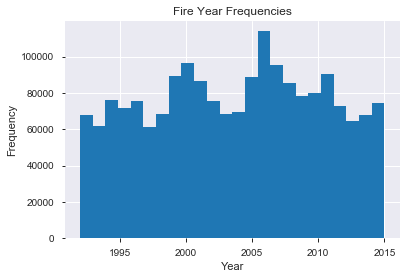

```python
years = subset["FIRE_YEAR"]
plt.hist(years, bins=len(subset["FIRE_YEAR"].unique()))
plt.title("Fire Year Frequencies")
plt.xlabel("Year")
plt.ylabel("Frequency")
plt.show()
```

```python
def make_hist_by_state_and_fire_year(state, dframe):
    """
    """
    stateframe = dframe[dframe['STATE']==state]
    years = stateframe["FIRE_YEAR"]
    print("state: {}\nnbr records: {}".format(state, len(years)))
    plt.hist(years, bins=len(stateframe["FIRE_YEAR"].unique()))
    plt.title("Fire Year Frequencies")
    plt.xlabel("Year")
    plt.ylabel("Frequency")
    plt.savefig("{}.png".format(state))
```

```python
dist_subset = subset[["FIRE_YEAR", "STATE"]]
states = dist_subset["STATE"].unique()
states
```

```
array(['CA', 'NM', 'OR', 'NC', 'WY', 'CO', 'WA', 'MT', 'UT', 'AZ', 'SD',
       'AR', 'NV', 'ID', 'MN', 'TX', 'FL', 'SC', 'LA', 'OK', 'KS', 'MO',
       'NE', 'MI', 'KY', 'OH', 'IN', 'VA', 'IL', 'TN', 'GA', 'AK', 'ND',
       'WV', 'WI', 'AL', 'NH', 'PA', 'MS', 'ME', 'VT', 'NY', 'IA', 'DC',
       'MD', 'CT', 'MA', 'NJ', 'HI', 'DE', 'PR', 'RI'], dtype=object)
```

```
state: CA
nbr records: 189550
state: NM
nbr records: 37478
state: OR
nbr records: 61088
state: NC
nbr records: 111277
state: WY
nbr records: 14166
state: CO
nbr records: 34157
state: WA
nbr records: 33513
state: MT
nbr records: 40767
state: UT
nbr records: 30725
state: AZ
nbr records: 71586
state: SD
nbr records: 30963
state: AR
nbr records: 31663
state: NV
nbr records: 16956
state: ID
nbr records: 36698
state: MN
nbr records: 44769
state: TX
nbr records: 142021
state: FL
nbr records: 90261
state: SC
nbr records: 81315
state: LA
nbr records: 30013
state: OK
nbr records: 43239
```

[output cut: 49 more lines]

```
nbr records: 3622
state: CT
nbr records: 4976
state: MA
nbr records: 2626
state: NJ
nbr records: 25949
state: HI
nbr records: 9895
state: DE
nbr records: 171
state: PR
nbr records: 22081
state: RI
nbr records: 480
```

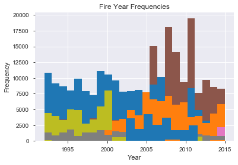

```python
for state in states:
    make_hist_by_state_and_fire_year(state, dist_subset)
```

```python
# sns.distplot(dist_subset)

# not working; my vision for this is to see quantities in each fire year by state
```

```python
# sns.boxplot(x="STATE", y = "FIRE_SIZE", data = box_subset, orient = "h")
# sns.swarmplot(x="STATE", y = "FIRE_SIZE", data = box_subset, color = "0.25")

# not working; my vision for this is to see fire size by state
```